# Time_series

## Key Concepts: Autocorrelation/Autocovariance

Autocorrelation/autocovariance refers to the correlation/covariance between two observations in the time series at different points.

The central idea behind it is how related the data/time series is over time.

When analyzing time series we usually view autocorrelation/partial autocorrelation in ACF/PACF plots.

```r
# help function
# function to similate random walk
sim.random.walk<-function(seed=30,n=1000,random.mean=0,random.sd=1) {data.frame("t"=1:n,"X"=cumsum(rnorm(n,random.mean,random.sd)))}
```

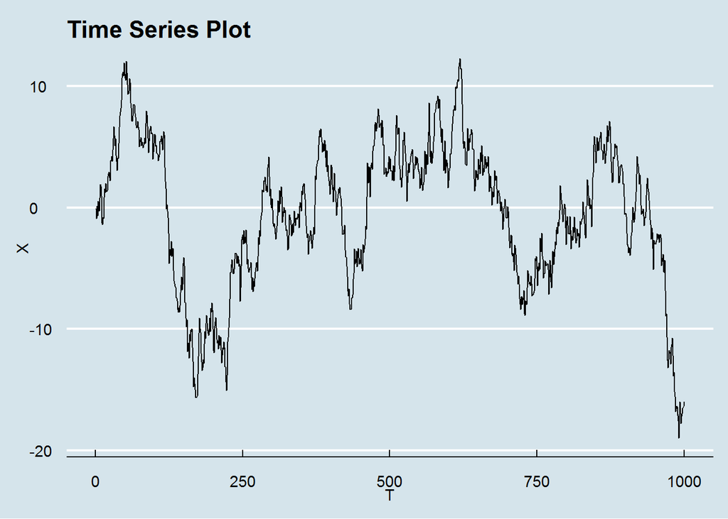

```r
#simulate random walk
dat<-sim.random.walk()

#plot random walk
dat %>% ggplot(aes(t,X)) + geom_line() + xlab("T") + ylab("X") + ggtitle("Time Series Plot")
```

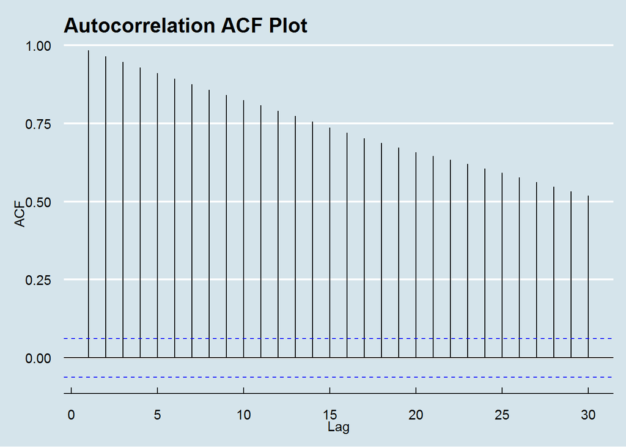

```r
#ACF plot
ggAcf(dat$X,type="correlation") + ggtitle("Autocorrelation ACF Plot")
```

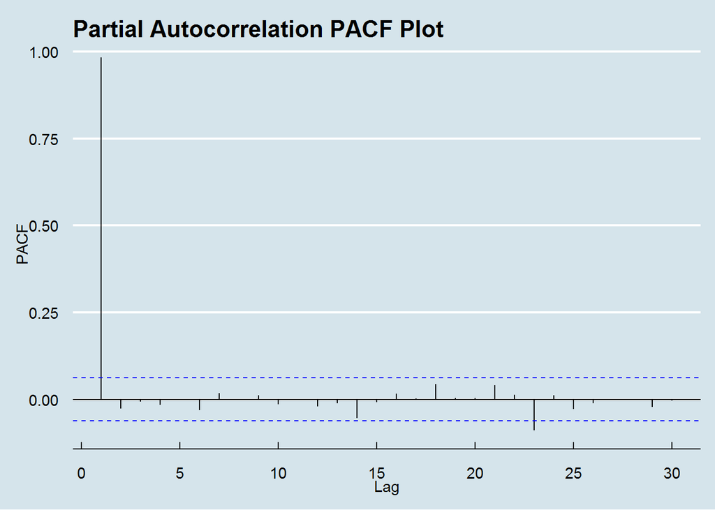

```r
#PACF plot
ggAcf(dat$X,type="partial") + ggtitle("Partial Autocorrelation PACF Plot")
```

## Key Concepts: Stationarity

The second key concept in time series is stationarity.

While the concept can get quite technical, the basic idea is examining whether the distribution of the data over time is consistent.

There are two main forms of stationarity.

1. Strict stationarity imples:

The cumulative distribution function of the data does not depend on time:

$F_X(X_1,…,X_T)=F_X(X_{1+\Delta},…,X_{T+\Delta})$ $\forall \Delta\in\mathbb{R}$

2. Weak stationarity implies:

- the mean of the time series is constant

$E(X_t)=E(X_{t+\Delta})$

- the autocovariance/autocorrelation only depends on the time difference between points

$ACF(X_{t},X_{t+\Delta-1})=ACF(X_1,X_{\Delta})$

- the time series has a finite variance

$Var(X_\Delta)<\infty$ $\forall \Delta\in\mathbb{R}$

## Checking for Stationarity

```r
## help function
sim.stationary.example<-function(seed=30,n=1000,random.mean=0,random.sd=1,B=1) {
  data.frame("t"=1:n,
             #nonstationary; differencing
             "X1"=cumsum(rnorm(n,random.mean,random.sd)),
             #nonstationary; detrending
             "X2"=B*(1:n)+rnorm(n,random.mean,random.sd),
             #stationary
             "X3"=rnorm(n,random.mean,random.sd))
}
```

```r
#create three time series for example
df<-sim.stationary.example(n=1000)
```

Check a plot of the time series over time and look for constant mean and finite variance i.e. values appear bounded.

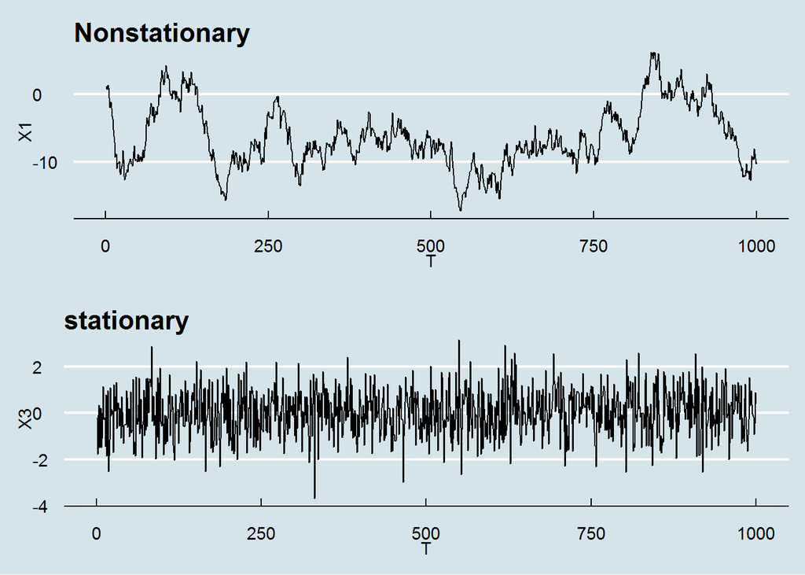

```r
#plot nonstationary and stationary time series
g1 <- ggplot(data = df , aes(x = t , y= X1)) +
      geom_line()+
      xlab("T") +
      ylab("X1")+
      ggtitle("Nonstationary")

g2 <- ggplot(data = df , aes(x = t , y= X3)) +
      geom_line()+
      xlab("T") +
      ylab("X3")+
      ggtitle("stationary")

grid.arrange(g1,g2)
```

Look at the ACF plot and see if it dies off quickly as opposed to a gradual decline.

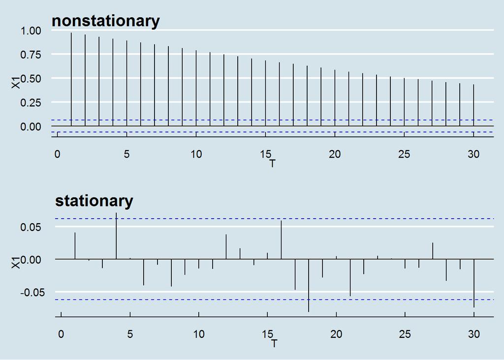

```r
#ACF for nonstationary and stationary time series
g1 <- ggAcf(df$X1 , type = "correlation") +
    xlab("T") +
    ylab("X1") +
    ggtitle("nonstationary")

g2 <- ggAcf(df$X3 , type = "correlation")+
    xlab("T") +
    ylab("X1")+
    ggtitle("stationary")

grid.arrange(g1,g2)
```

Perform unit root tests such as the Augmented DickeyÂFuller test.

```r
#perform unit test; nonstationary example has large, non-significant p-value
adf.test(df$X1)
```

```
##
##  Augmented Dickey-Fuller Test
##
## data:  df$X1
## Dickey-Fuller = -3.3003, Lag order = 9, p-value = 0.07063
## alternative hypothesis: stationary
```

```r
#perform unit test; stationary example has small, significant p-value
adf.test(df$X3)
```

```
##
##  Augmented Dickey-Fuller Test
##
## data:  df$X3
## Dickey-Fuller = -10.812, Lag order = 9, p-value = 0.01
## alternative hypothesis: stationary
```

## Transforming for Stationarity

### Differencing

Differencing involves taking differences between successive time series values.

The order of differencing is defined as p for $X_t-X_{t-p}$.

Let’s transform a nonstationary time series to stationary by differencing with the random walk model.

In a random walk $X_t=X_{t-1}+\epsilon_t$ where $\epsilon_t\sim N(0,\sigma^2)$ iid.

Differencing with an order of one means that $\tilde{X}_t=X_t-X_{t-1}=\epsilon_t$.

```r
#difference time series to make stationary
diff <- df$X1 - lag(df$X1,1)
```

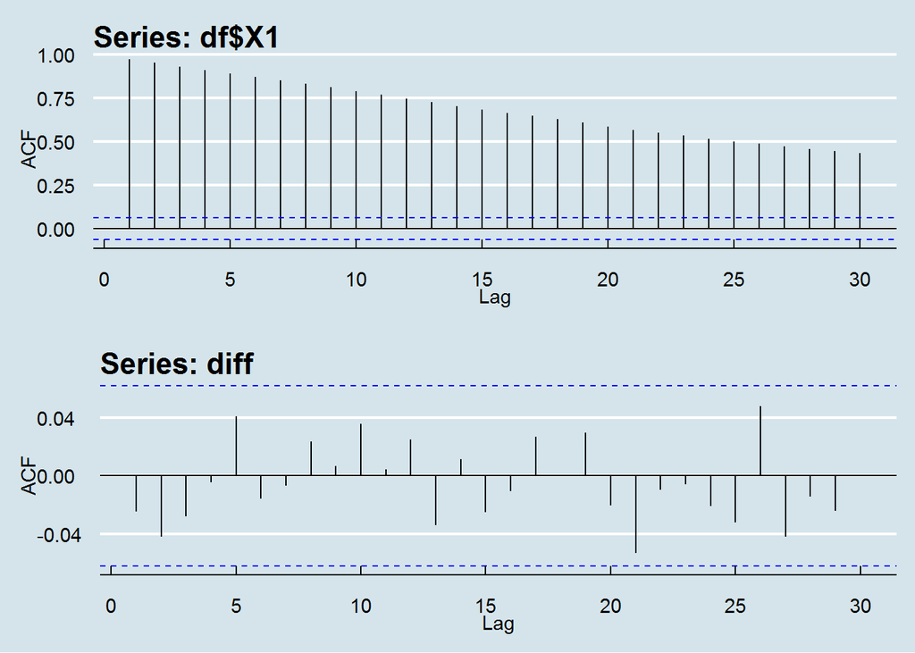

```r
#plot original and differenced time series
g1 <- ggAcf(df$X1 , type = "correlation")
g2 <- ggAcf(diff , type = "correlation")

grid.arrange(g1,g2)
```

## Detrending

Detrending involves removing a deterministic relationship with time.

As an example suppose we have the following data generating process $X_t=B_t+\epsilon_t$ where $\epsilon_t\sim N(0,\sigma^2)$ iid.

Detrending involves using the transformed time series $\tilde{X}_t=X_t-Bt=\epsilon_t$.

```r
#detrend time series to make stationary
```

[output not shown]

```r
#plot original and detrended time series
```

[output not shown]

Basic Model Types: AR(p), MA(q), ARMA(p,q), ARIMA(p,d,q), Decomposition

Autoregressive AR(p) Models

When fitting an AR model the key choice is p, the number of lags to include.

Moving Average MA(q) Models

Similar to an AR model, when fitting an MA model the key choice is q, the number of random shock lags.

Autoregressive Moving Average ARMA(p,q) Models

When fitting an ARMA model, we need to choose two things: p, the number of AR lags, and q, the number of MA lags.

Autoregressive Integrated Moving Average ARIMA(p,d,q) Models

ARIMA(p,d,q) is an ARMA model with differencing.

When fitting an ARIMA model we need to choose three things: p, the number of AR lags, q, the number of MA lags, and d, the number of differences to use.

Decomposition ModelsÂ¶

There are various ways to estimate the different trend components: exponential smoothing, state space models/Kalman filtering, STL models, etc.

In this project we will cover STL models because of their ease of use and flexibility.

Fitting AR/MA/ARMA/ARIMA models with the Box Jenkins Method

We will now go over how to fit AR/MA/ARMA/ARIMA models on a real data set and review a generic strategy for fitting them known as the Box Jenkins method.

This process involves several steps to help identify the p, d, and q parameters that we need:

Identify whether the time series is stationary or not

Identify p, d, and q of the time series by

Making the the time series stationary through differencing/detrending to find d

Looking at ACF/PACF to find p and q

Using model fit diagnostics like AIC or BIC to select the best model to find p, d, and q

Check the model fit using the LjungÂBox test

```r
#load data
ur = read.csv("data/Mass_Monthly_Unemployment_Rate.csv")
```

```r
# check date class
class(ur$DATE)
```

```
## [1] "character"
```

```r
#change date class to date type
ur$DATE <- as.Date(ur$DATE)
class(ur$DATE)
```

```
## [1] "Date"
```

## Checking for Stationarity

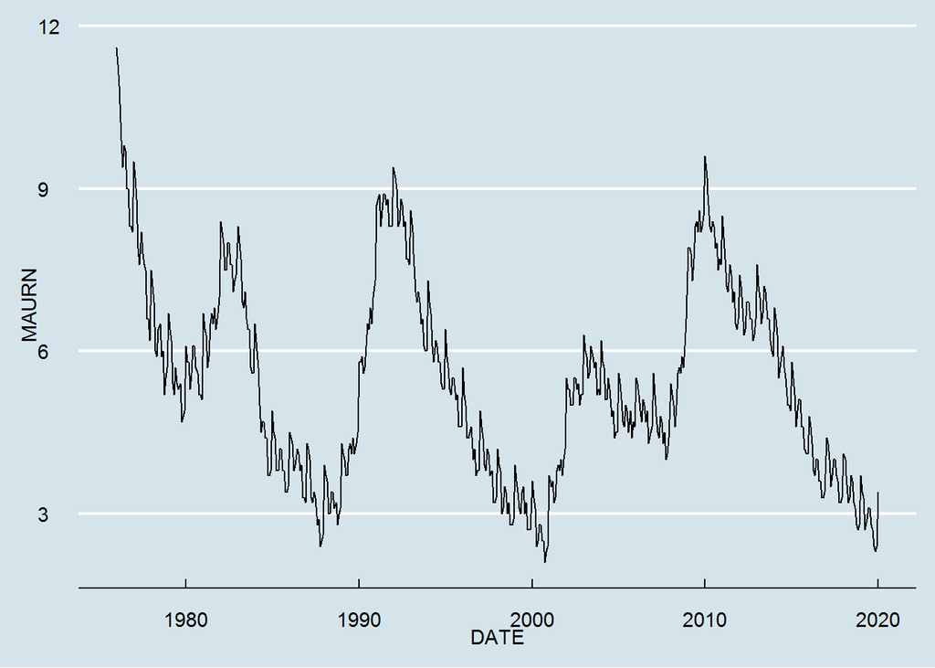

```r
#check time series plot
ggplot(ur,aes(x= DATE , y= MAURN)) + geom_line()
```

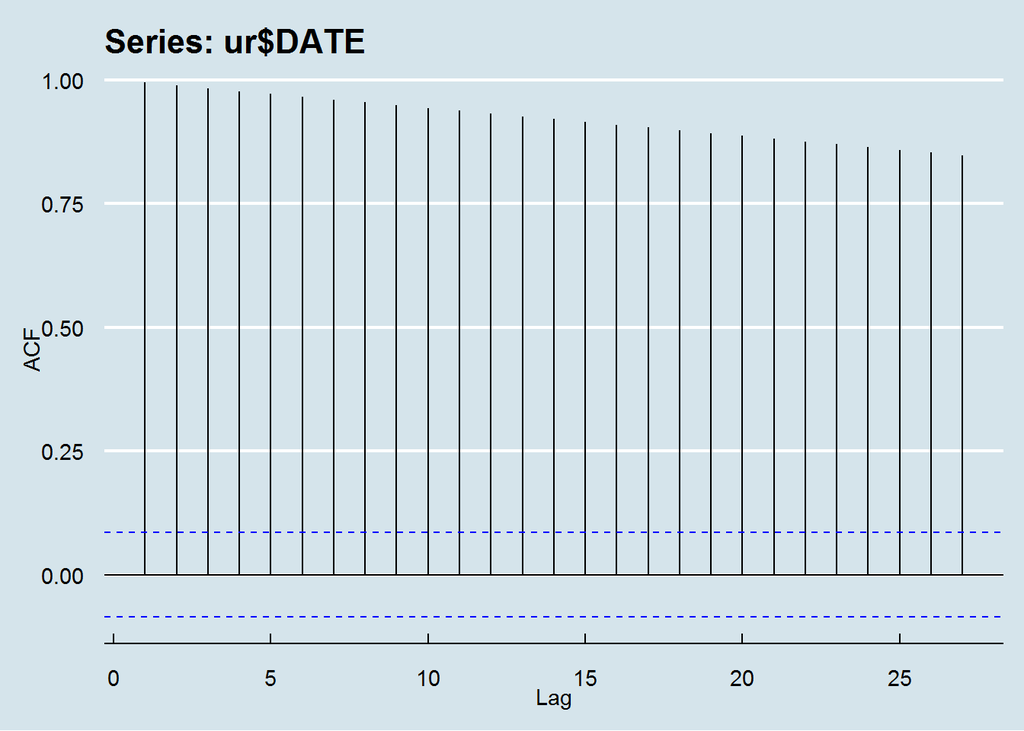

```r
#check ACF plot
ggAcf(ur$DATE , type = "correlation")
```

```r
#run ADF test
adf.test(ur$DATE)
```

```
##
##  Augmented Dickey-Fuller Test
##
## data:  ur$DATE
## Dickey-Fuller = -8.3024, Lag order = 8, p-value = 0.01
## alternative hypothesis: stationary
```

## Transforming for Stationarity & Identifying Model Parameters

```r
# fit AR model
ar.model = auto.arima(ur$MAURN , max.d = 0 ,max.q = 0 ,allowdrift =T)
ar.model
```

```
## Series: ur$MAURN
## ARIMA(1,0,0) with non-zero mean
##
## Coefficients:
##          ar1    mean
##       0.9787  5.7425
## s.e.  0.0101  0.8498
##
## sigma^2 estimated as 0.2:  log likelihood=-325.44
## AIC=656.88   AICc=656.93   BIC=669.7
```

```r
# fit ma model
ma.model = auto.arima(ur$MAURN , max.d = 0 ,max.p = 0 ,allowdrift =T)
ma.model
```

```
## Series: ur$MAURN
## ARIMA(0,0,5) with non-zero mean
##
## Coefficients:
##          ma1     ma2     ma3     ma4     ma5    mean
##       1.3646  1.7103  1.4882  1.2714  0.4804  5.4588
## s.e.  0.0368  0.0492  0.0578  0.0393  0.0350  0.1507
##
## sigma^2 estimated as 0.229:  log likelihood=-361.03
## AIC=736.05   AICc=736.27   BIC=765.95
```

```r
# fit ARMA model
arma.model = auto.arima(ur$MAURN , max.d = 0  ,allowdrift =T)
arma.model
```

```
## Series: ur$MAURN
## ARIMA(3,0,2) with non-zero mean
##
## Coefficients:
##           ar1     ar2     ar3     ma1     ma2    mean
##       -0.2267  0.5998  0.5573  1.3361  0.8876  5.7038
## s.e.   0.0885  0.0544  0.0569  0.0544  0.0221  0.7764
##
## sigma^2 estimated as 0.1693:  log likelihood=-280.15
## AIC=574.3   AICc=574.51   BIC=604.19
```

```r
# fit ARiMA model
arima.model = auto.arima(ur$MAURN  ,allowdrift =T)
arima.model
```

```
## Series: ur$MAURN
## ARIMA(4,1,2)
##
## Coefficients:
##          ar1      ar2      ar3     ar4      ma1     ma2
##       1.0029  -0.1834  -0.3982  0.4872  -1.1149  0.2512
## s.e.  0.0708   0.0750   0.0560  0.0394   0.0793  0.0711
##
## sigma^2 estimated as 0.1509:  log likelihood=-247.45
## AIC=508.9   AICc=509.12   BIC=538.78
```

## Checking the Residuals of the Model Fit

```r
#calculate residuals of each model
ar.residual <- resid(ar.model)
ma.residual <- resid(ma.model)
arma.residual <- resid(arma.model)
arima.residual <- resid(arima.model)
```

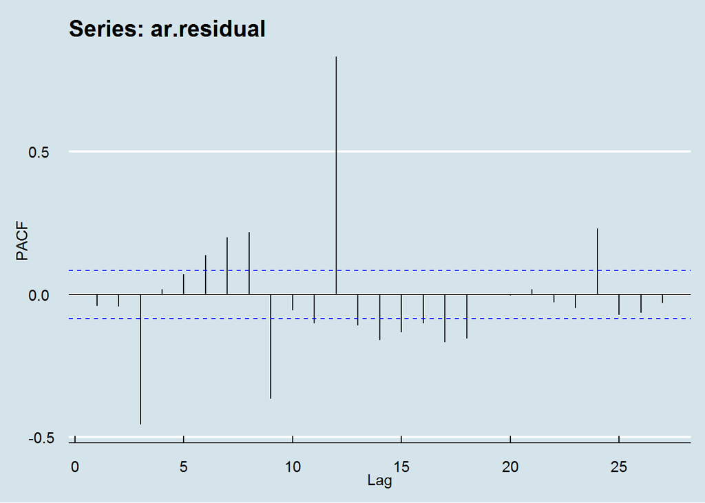

```r
#plot PACF plot of each models residuals
ggAcf(ar.residual, type ="partial")
```

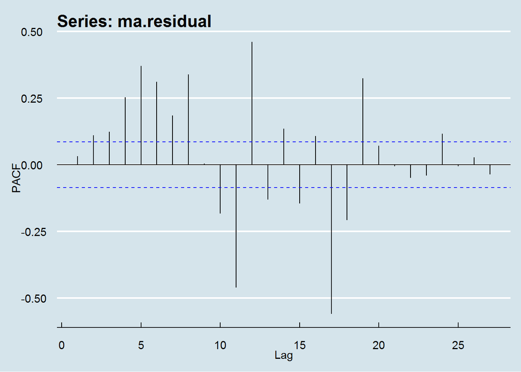

```r
ggAcf(ma.residual, type ="partial")
```

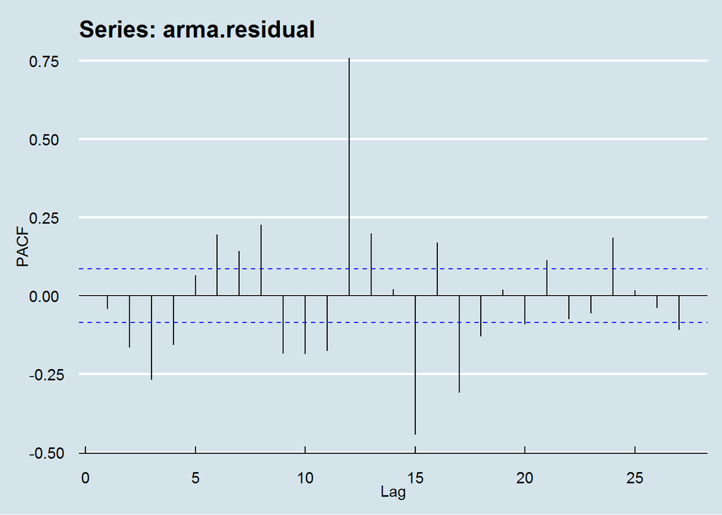

```r
ggAcf(arma.residual, type ="partial")
```

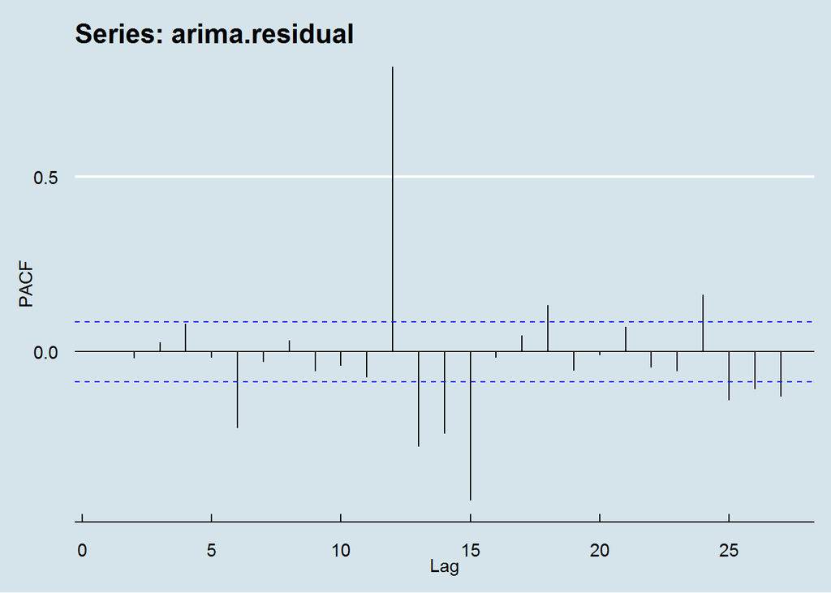

```r
ggAcf(arima.residual, type ="partial")
```

```r
#run the Ljung Box test on the residuals
Box.test(ar.residual , type = "Ljung-Box" ,lag = 1)
```

```
##
##  Box-Ljung test
##
## data:  ar.residual
## X-squared = 0.88802, df = 1, p-value = 0.346
```

```r
Box.test(ma.residual , type = "Ljung-Box" ,lag = 1)
```

```
##
##  Box-Ljung test
##
## data:  ma.residual
## X-squared = 0.56386, df = 1, p-value = 0.4527
```

```r
Box.test(arma.residual , type = "Ljung-Box" ,lag = 1)
```

```
##
##  Box-Ljung test
##
## data:  arma.residual
## X-squared = 0.96747, df = 1, p-value = 0.3253
```

```r
Box.test(arima.residual , type = "Ljung-Box" ,lag = 1)
```

```
##
##  Box-Ljung test
##
## data:  arima.residual
## X-squared = 0.0032696, df = 1, p-value = 0.9544
```

## Making a forecast for each model

```r
#make forecast for each model
ar.forecast <- forecast(ar.model , h = 24 , level =80)
ma.forecast <- forecast(ma.model , h = 24 , level =80)
arma.forecast <- forecast(arma.model , h = 24 , level =80)
arima.forecast <- forecast(arima.model , h = 24 , level =80)
```

```r
#plot forecast for each model
g1 <- autoplot(ar.forecast)
g2 <- autoplot(ma.forecast)
g3 <- autoplot(arma.forecast)
g4 <- autoplot(arima.forecast)
```

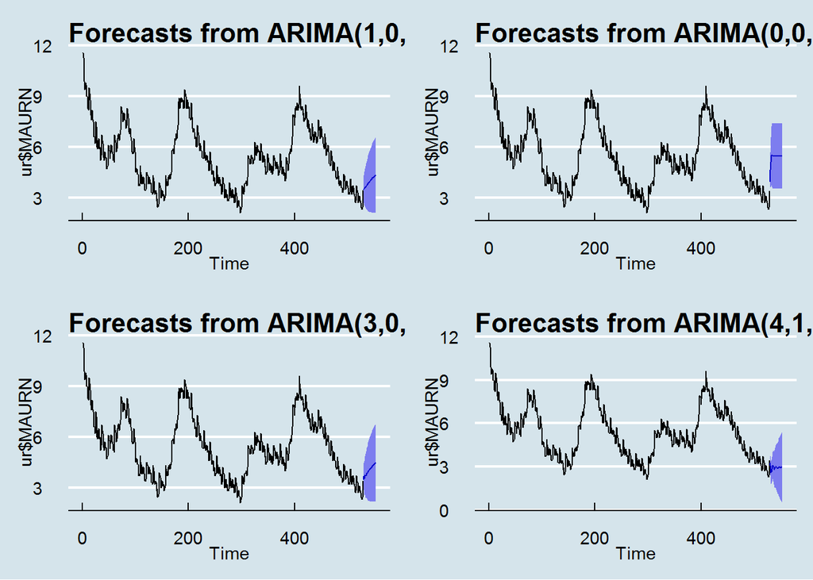

```r
grid.arrange(g1,g2,g3,g4,nrow =2 , ncol =2)
```

## Fitting Seasonal Trend Loess (STL) Decomposition Models

```r
#transform to time series object; need to specify frequency
ur.ts = ts(ur$MAURN , frequency = 12)
```

```r
#fit stil model
stl.model <- stl(ur.ts , s.window =  "periodic")
```

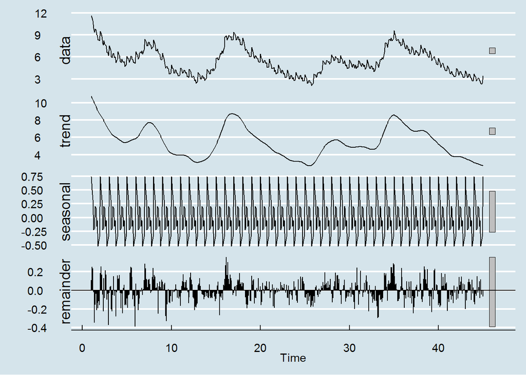

```r
#plot model fit
autoplot(stl.model)
```

```r
#make forecast
stl.forecast = forecast(stl.model , h= 24 , level =80)
```

## Where to go Next

- Advanced time series models

- ARCH, GARCH, etc. that model changing variance over time

- Vector Autoregression (VAR)

- For multivariate i.e. multiple time series and modeling dependencies between them

- Machine Learning

- How to do CV with time series
- Neural networks for sequence data (LSTMs, etc.)

- Spatial Statistics

- Generalize time dependence to spatial dependence in multiple dimensions

- Econometrics

- Cointegration
- Granger Causality
- Serial correlation
- Regression with time series data

- Bayesian time series